# R Visualization Portfolio Project

## Flipper and body mass in orange

Here, we plot flipper length against body mass with coloring all the points

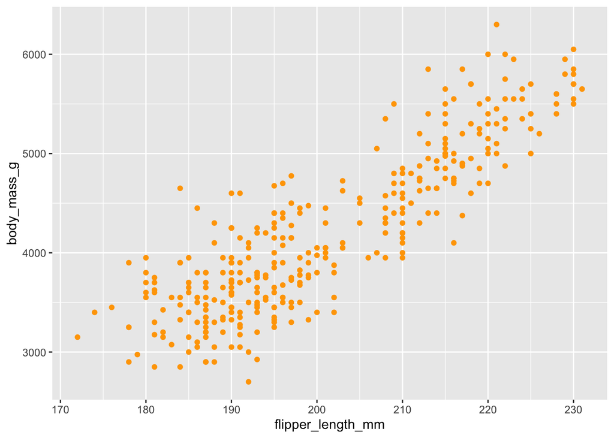

```r
ggplot(data=penguins) + geom_point(mapping = aes(x=flipper_length_mm,y=body_mass_g),color="orange")
```

## Flipper and body mass in a smooth way

Here, we plot flipper length against body mass in a smooth way

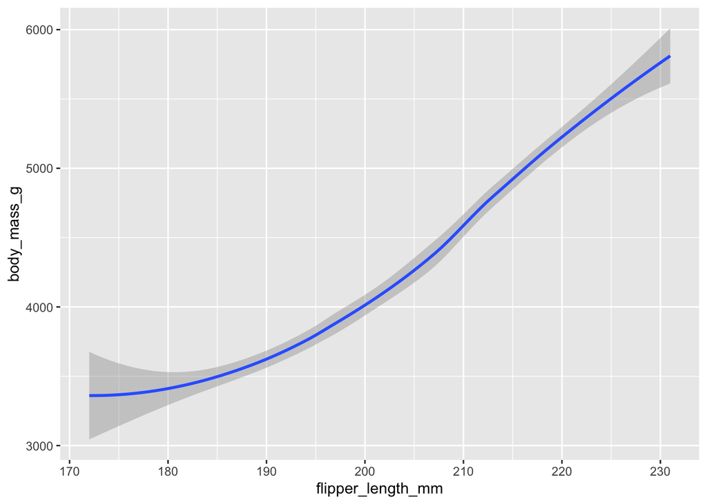

```r
ggplot(data=penguins) + geom_smooth(mapping = aes(x=flipper_length_mm,y=body_mass_g))
```

## Flipper and body mass two ways represntation

Here we will combine the points with smooth function

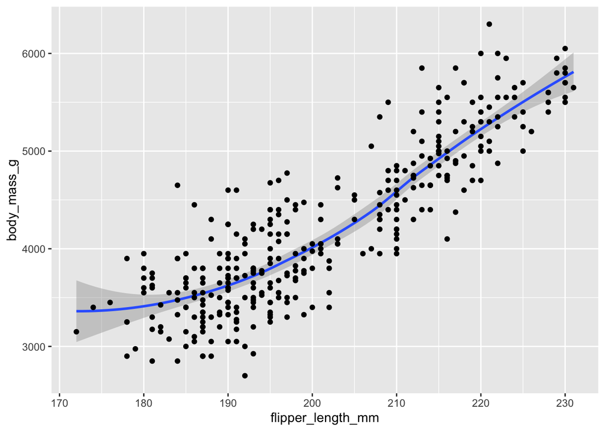

```r
ggplot(data=penguins) + geom_smooth(mapping = aes(x=flipper_length_mm,y=body_mass_g)) +
  geom_point(mapping = aes(x=flipper_length_mm,y=body_mass_g))
```

## Flipper and body mass by species in smooth way

Here, we plot flipper length against body mass and separating each species

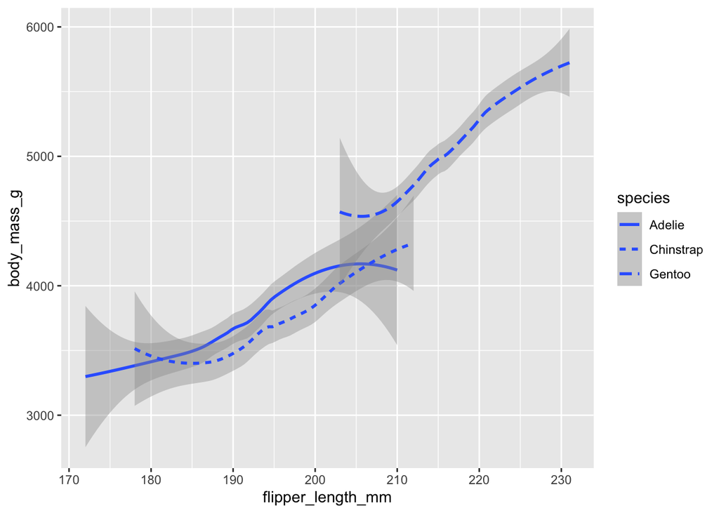

```r
ggplot(data=penguins) +
  geom_smooth(mapping = aes(x=flipper_length_mm,y=body_mass_g, linetype=species))
```

Here, we plot flipper length against body mass and add a small amount of random variation to the location of each point in a graph

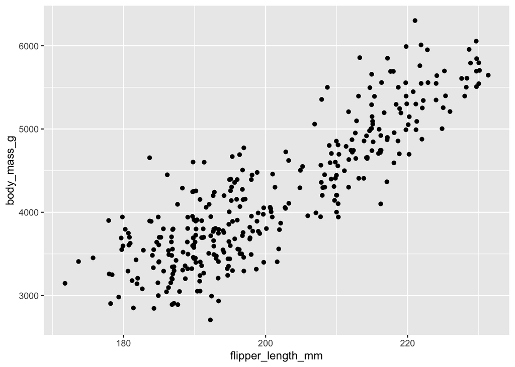

```r
ggplot(data=penguins) +
  geom_jitter(mapping = aes(x=flipper_length_mm,y=body_mass_g))
```

## Flipper and body mass by species and sex

Here, we plot flipper length against body mass and look at the breakdown by species and sex

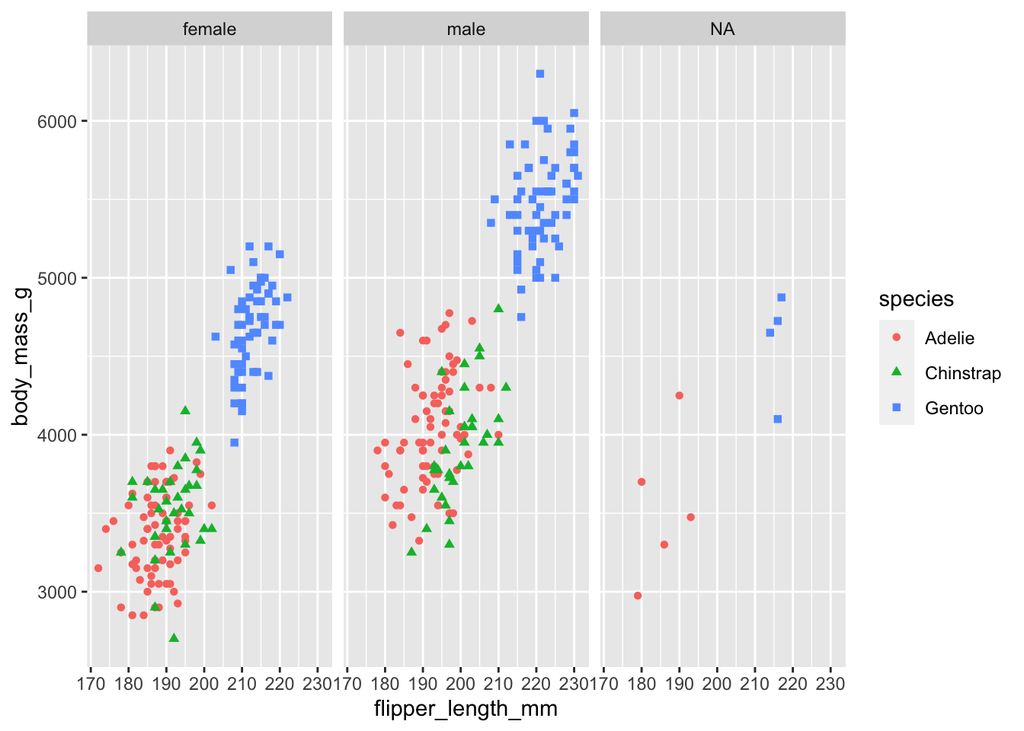

```r
ggplot(data=penguins,aes(x=flipper_length_mm,y=body_mass_g))+
  geom_point(aes(color=species,shape=species))+

  facet_wrap(~sex)
```

## Cut of the diamonds

Here, we are going to use diamonds data set with bar graphs, and look at the breakdown by cut.

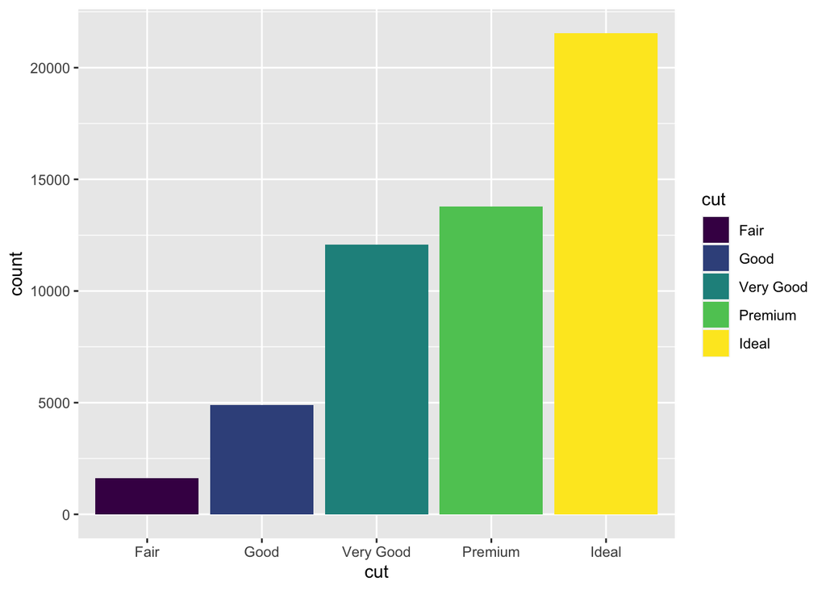

```r
ggplot(data=diamonds)+
  geom_bar(mapping = aes(x=cut, fill=cut ))
```

## Cut of the diamonds

Here, we we plot cut breakdown by clarity

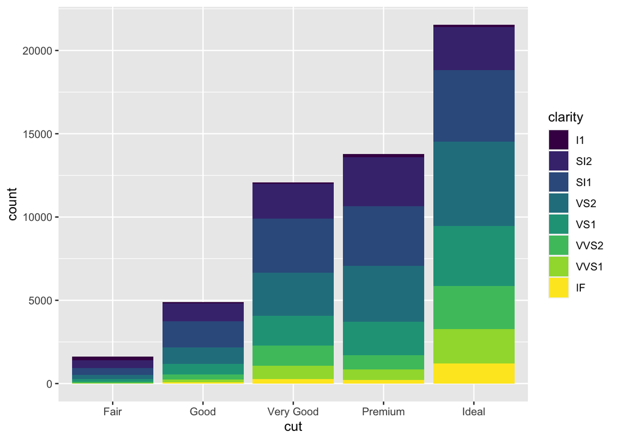

```r
ggplot(data=diamonds)+
  geom_bar(mapping = aes(x=cut, fill=clarity ))
```

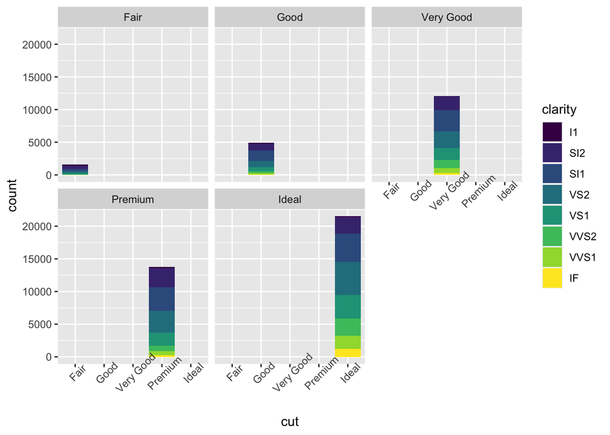

```r
ggplot(data=diamonds)+
  geom_bar(mapping = aes(x=cut, fill=clarity )) + theme(axis.text.x = element_text(angle = 45))+
  facet_wrap(~cut)
```